# Analysis: Semantic shift of Trump

Replicated from *Embedding Regression: Models for Context-Specific Description and Inference* (Rodriguez et al., 2023)

Author

Bridgette Sullivan & Maria Bartlett

Published

April 3, 2025

**Research question:** Was the word “Trump” used differently post-2016 U.S. election relative to the word “Clinton”?

### Step 1: Import 3 required inputs

1. Corpus (New York Times articles)

```r
# --------------------------------
# load data
# --------------------------------

# nyt corpus
corpus_nyt <- readRDS(file.path(author_rep,"data","nyt_data.rds")) %>%
  # data contains 3 million + articles
  verify(nrow(.) == 3032517 & ncol(.) == 6) %>%
  verify(names(.) %in% c("snippet","lead_paragraph","web_url","date","year","month")) %>%
  verify(min(year) == 1990 & max(year) == 2020)

# impute lead paragraph with snippet when lead paragraph is missing
corpus_nyt$lead_paragraph[is.na(corpus_nyt$lead_paragraph)] <- corpus_nyt$snippet[is.na(corpus_nyt$lead_paragraph)]
```

2. GloVe pre-trained embeddings (400,000 x 300)

```r
# pre-trained GloVe embeddings
pre_trained <- readRDS(file.path(author_rep,"data","stanford-glove","glove.rds"))

# confirm GloVe is comprised of 300-dimension embeddings for 400,000 tokens
stopifnot(nrow(pre_trained) == 400000 & ncol(pre_trained) == 300)

# look at head of GloVe embeddings
head(as.data.frame(pre_trained)) %>% kable_style()
```

|  | V1 | V2 | V3 | V4 | V5 | V6 | V7 | V8 | V9 | V10 | V11 | V12 | V13 | V14 | V15 | V16 | V17 | V18 | V19 | V20 | V21 | V22 | V23 | V24 | V25 | V26 | V27 | V28 | V29 | … |
| --- | --- | --- | --- | --- | --- | --- | --- | --- | --- | --- | --- | --- | --- | --- | --- | --- | --- | --- | --- | --- | --- | --- | --- | --- | --- | --- | --- | --- | --- | --- |
| the | 0.046560 | 0.213180 | -0.0074364 | -0.458540 | -0.035639 | 0.236430 | -0.288360 | 0.215210 | -0.134860 | -1.6413 | -0.26091 | 0.032434 | 0.056621 | -0.0432960 | -0.021672 | 0.2247600 | -0.075129 | -0.067018 | -0.1424700 | 0.038825 | -0.189510 | 0.29977 | 0.393050 | 0.178870 | -0.173430 | -0.211780 | 0.236170 | -0.0636810 | -0.423180 | … |
| , | -0.255390 | -0.257230 | 0.1316900 | -0.042688 | 0.218170 | -0.022702 | -0.178540 | 0.107560 | 0.058936 | -1.3854 | 0.58509 | 0.036501 | -0.198460 | 0.1961300 | 0.409290 | 0.1570200 | -0.153050 | 0.050447 | 0.3004500 | -0.112950 | -0.017043 | 0.18593 | 0.199820 | 0.200530 | -0.631410 | -0.126220 | 0.295100 | -0.2628200 | -0.158310 | … |
| . | -0.125590 | 0.013630 | 0.1030600 | -0.101230 | 0.098128 | 0.136270 | -0.107210 | 0.236970 | 0.328700 | -1.6785 | 0.22393 | 0.124090 | -0.086708 | 0.3301000 | 0.343750 | -0.0008758 | -0.296580 | 0.244170 | -0.1159200 | -0.035742 | -0.010830 | 0.20776 | 0.292850 | -0.073491 | -0.185980 | -0.200900 | -0.095366 | 0.0063732 | -0.136200 | … |
| of | -0.076947 | -0.021211 | 0.2127100 | -0.722320 | -0.139880 | -0.122340 | -0.175210 | 0.121370 | -0.070866 | -1.5721 | -0.22464 | 0.042690 | -0.401800 | 0.2100600 | 0.014288 | 0.4162800 | 0.017165 | 0.071732 | 0.0069246 | 0.181070 | -0.154120 | 0.14933 | -0.030493 | 0.299180 | 0.029479 | -0.036147 | -0.061125 | 0.0839180 | -0.123980 | … |
| to | -0.257560 | -0.057132 | -0.6719000 | -0.380820 | -0.364210 | -0.082155 | -0.010955 | -0.082047 | 0.460560 | -1.8477 | -0.11258 | -0.129550 | 0.272540 | 0.0072891 | 0.260380 | 0.1209600 | -0.231930 | 0.032260 | -0.2947200 | -0.675940 | -0.338440 | -0.23297 | 0.110200 | 0.188160 | -0.451840 | -0.338330 | 0.112740 | 0.4949000 | -0.042132 | … |
| and | 0.038466 | -0.039792 | 0.0827470 | -0.389230 | -0.214310 | 0.170200 | -0.025657 | 0.095780 | 0.238600 | -1.6342 | 0.14332 | -0.037958 | -0.019583 | 0.3849400 | 0.097319 | 0.2969700 | -0.345230 | 0.117420 | -0.0241890 | 0.160130 | 0.098240 | 0.12811 | -0.174820 | 0.209760 | -0.223620 | -0.206560 | 0.244280 | 0.0668750 | -0.125940 | … |

3. Pre-trained transformation matrix (300 x 300)

```r
# pre-trained transformation matrix (A_hat)
transform_matrix <- readRDS(file.path(author_rep,"data","stanford-glove","khodakA.rds"))

# confirm transformation matrix is 300 x 300
stopifnot(nrow(transform_matrix) == 300 & ncol(transform_matrix) == 300)

# look at head of transformation matrix
head(as.data.frame(transform_matrix)) %>% kable_style()
```

| V1 | V2 | V3 | V4 | V5 | V6 | V7 | V8 | V9 | V10 | V11 | V12 | V13 | V14 | V15 | V16 | V17 | V18 | V19 | V20 | V21 | V22 | V23 | V24 | V25 | V26 | V27 | V28 | V29 | V30 | … |
| --- | --- | --- | --- | --- | --- | --- | --- | --- | --- | --- | --- | --- | --- | --- | --- | --- | --- | --- | --- | --- | --- | --- | --- | --- | --- | --- | --- | --- | --- | --- |
| 0.5607746 | 0.0550748 | 0.0495107 | -0.0464625 | -0.0106520 | 0.0344103 | 0.0656478 | -0.0053072 | 0.0295462 | -0.0315206 | -0.0785059 | 0.0020340 | -0.0132530 | -0.0078540 | -0.0048011 | -0.0253540 | -0.0119036 | 0.0174734 | 0.0242859 | -0.0260771 | -0.0200459 | 0.0032073 | -0.0042882 | 0.0560995 | -0.0063097 | 0.0046477 | -0.0264510 | -0.0277475 | 0.0122809 | -0.0298047 | … |
| 0.0416596 | 0.5630122 | 0.0106112 | -0.0191296 | -0.0334351 | -0.0902052 | 0.0166571 | -0.0557118 | 0.0063888 | -0.0011801 | 0.0278773 | 0.0351404 | -0.0229873 | 0.0010008 | 0.0055337 | -0.0025261 | -0.0315132 | -0.0622844 | -0.0027920 | -0.0095651 | 0.0039516 | -0.0031745 | -0.0078614 | -0.0152983 | -0.0085121 | 0.0106074 | 0.0416580 | -0.0490234 | -0.0504771 | 0.0281772 | … |
| 0.0046441 | -0.0228808 | 0.5448614 | 0.0246440 | -0.0207175 | -0.0012490 | -0.0307474 | 0.0059976 | 0.0133589 | -0.0121156 | -0.0146690 | -0.0352844 | 0.0297164 | -0.0338550 | 0.0129875 | -0.0240267 | 0.0118902 | -0.0393049 | 0.0466910 | 0.0307640 | -0.0030217 | -0.0167317 | 0.0387442 | 0.0132183 | -0.0282691 | -0.0009461 | -0.0001940 | 0.0422772 | 0.0574634 | -0.0181677 | … |
| 0.0066424 | -0.0074119 | -0.0313813 | 0.5991896 | -0.0337478 | 0.0434845 | 0.0227748 | -0.0151823 | -0.0031857 | -0.0493826 | 0.0021091 | -0.0162135 | -0.0169861 | -0.0196965 | -0.0017261 | 0.0082552 | 0.0428571 | 0.0080955 | 0.0204760 | -0.0083306 | -0.0243268 | -0.0269508 | 0.0290062 | -0.0089827 | -0.0030921 | -0.0305094 | 0.0021907 | -0.0089037 | 0.0084310 | 0.0138914 | … |
| -0.0391690 | 0.0152768 | -0.0242715 | 0.0002657 | 0.6029815 | 0.0224104 | 0.0081243 | 0.0266104 | -0.0160013 | -0.0042370 | 0.0210765 | -0.0212043 | 0.0159242 | 0.0151165 | 0.0718682 | 0.0116902 | -0.0280375 | 0.0097872 | 0.0151387 | -0.0248912 | -0.0184307 | -0.0468237 | 0.0119324 | -0.0823376 | -0.0476754 | -0.0006327 | 0.0301695 | -0.0149467 | 0.0609515 | -0.0222411 | … |
| 0.0028063 | 0.0063796 | -0.0077214 | -0.0373654 | 0.0037413 | 0.5545734 | -0.0180804 | 0.0324902 | 0.0094259 | -0.0211481 | -0.0513154 | -0.0008463 | -0.0209440 | -0.0116707 | 0.0324731 | 0.0333456 | 0.0296010 | 0.0195870 | 0.0087085 | 0.0249044 | 0.0056489 | 0.0026517 | -0.0153014 | -0.0351541 | -0.0351425 | 0.0206675 | -0.0129213 | 0.0424743 | -0.0028965 | -0.0326627 | … |

### Step 2: Subset corpus to articles of interest

Keep only articles from the NYT corpus that contain the strings ‘Trump’ or ‘Clinton’ (respecting case) between [2011,2014] and [2017,2020].

```r
# keep only documents where the target words appear: Trump
trump_corpus <- corpus_nyt[grep('Trump', corpus_nyt$lead_paragraph, fixed = TRUE, ignore.case = FALSE),
                           c('lead_paragraph', 'year')] %>%
  # 24,815 articles where 'Trump' appears in lead paragraph
  verify(nrow(.) == 24815) %>%
  distinct(lead_paragraph, .keep_all = TRUE) %>%
  # 17,802 articles once duplicates are dropped (if duplicates, first year in which article appeared is retained)
  verify(nrow(.) == 17802) %>%
  filter(year %in% c(2011:2014,2017:2020)) %>%
  # 11,675 articles once subset to period of interest
  verify(nrow(.) == 11675) %>%
  rename(text = lead_paragraph) %>%
  mutate(target = 'trump',
         year   = as.integer(year)) # uppercase matters here

# keep only documents where the target words appear: Clinton
clinton_corpus <- corpus_nyt[grep('Clinton', corpus_nyt$lead_paragraph, fixed = TRUE, ignore.case = FALSE),
                             c('lead_paragraph', 'year')] %>%
  # 45,463 articles where 'Clinton' appears in lead paragraph
  verify(nrow(.) == 45463) %>%
  distinct(lead_paragraph, .keep_all = TRUE) %>%
  # 44,591 articles once duplicates are dropped (if duplicates, first year in which article appeared is retained)
  verify(nrow(.) == 44591) %>%
  filter(year %in% c(2011:2014,2017:2020)) %>%
  # 1,622 articles once subset to period of interest
  verify(nrow(.) == 1622) %>%
  rename(text = lead_paragraph) %>%
  mutate(target = 'clinton',
         year   = as.integer(year))

# examine distribution of year in Clinton articles
count(clinton_corpus, year) %>% kable_style()
```

| year | n |
| --- | --- |
| 2011 | 337 |
| 2012 | 321 |
| 2013 | 193 |
| 2014 | 320 |
| 2017 | 146 |
| 2018 | 121 |
| 2019 | 135 |
| 2020 | 49 |

```r
# bind the two target word corpuses
sub_corpus <- rbind(trump_corpus, clinton_corpus)

# examine distribution of articles in each corpus
count(sub_corpus,target) %>% kable_style()
```

| target | n |
| --- | --- |
| clinton | 1622 |
| trump | 11675 |

**What does an example text look like at this point?**

```r
sub_corpus$text[1]
```

[1] “WASHINGTON — Federal agencies would no longer have to take climate change into account when they assess the environmental impacts of highways, pipelines and other major infrastructure projects, according to a Trump administration plan that would weaken the nation’s benchmark environmental law.”

### Step 3: Preprocess text

```r
# basic preprocessing of text
sub_corpus$text <- sub_corpus$text %>%
  gsub('Trump', 'toi', .) %>% # replace mentions of Trump with TOI (target of interest)
  gsub('Clinton', 'toi', .) %>% # replace mentions of Clinton with TOI (target of interest)
  gsub('LEAD:', '', .) %>% # remove header banner
  gsub("[^[:alpha:]]", " ", .) %>% # remove all non-alpha characters
  str_replace_all("\\b\\w{1,2}\\b", "") %>% # remove 1-2 letter words
  str_replace_all("^ +| +$|( ) +", "\\1") %>% # remove excess white space
  tolower() # lowercase
```

**What does the text from above look like at this point?**

```r
print(sub_corpus$text[1], max_nchar = 1000)
```

[1] “washington federal agencies would longer have take climate change into account when they assess the environmental impacts highways pipelines and other major infrastructure projects according toi administration plan that would weaken the nation benchmark environmental law”

### Step 4: Identify covariates

Covariates of interest:

- $Trump$: Whether article leading text contains string ‘Trump’ (vs. ‘Clinton’)
- $Post\_election$: Whether article was published during 2017-2020 (vs. 2011-2014)
- $Trump X Post\_election$: Interaction term

```r
# add dummy variables distinguishing pre-/post-election years and trump/clinton mentions
sub_corpus <- sub_corpus %>%
  mutate(post_election = if_else(year>2014, 1L, 0L),
         trump         = if_else(target == 'trump', 1L, 0L)) %>%
  mutate(interaction = trump*post_election)

# transform into quanteda corpus
sub_corpus <- corpus(sub_corpus$text, docvars = sub_corpus[,c("year", "target", "post_election", "trump", "interaction")])
toks       <- tokens(sub_corpus)
```

### Step 5: `conText` regression

$Focal\_word\_embedding = \beta_0 + \beta_1Trump + \beta_2Post\_election + \beta_3Trump X Post\_election + \epsilon$

**How is this outcome variable getting calculated in the regression?**

Context window: *and other major infrastructure projects according* **toi** *administration plan that would weaken the*

```r
# average 12 embeddings in 6-word window
embed <- (pre_trained["and",] + pre_trained["other",] + pre_trained["major",] + pre_trained["infrastructure",] +
          pre_trained["projects",] + pre_trained["according",] + pre_trained["administration",] +
          pre_trained["plan",] + pre_trained["that",] + pre_trained["would",] + pre_trained["weaken",] + pre_trained["the",]) / 12

as.data.frame(as.matrix(embed)) %>% head() %>% kable_style() # 300 x 1
```

| V1 |
| --- |
| -0.0400677 |
| 0.0882953 |
| -0.1992515 |
| -0.1349845 |
| -0.0352657 |
| 0.1592647 |

```r
# multiply by transformation matrix
transform <- transform_matrix %*% as.matrix(embed)

as.data.frame(as.matrix(transform)) %>% head() %>% kable_style() # this is the embedding outcome!
```

| V1 |
| --- |
| 0.0230084 |
| 0.0367123 |
| -0.1229871 |
| 0.0151769 |
| -0.0134428 |
| 0.1055920 |

#### conText regression

```r
# run regression
set.seed(2022L)

model1 <- conText(formula              = toi ~ trump + post_election + interaction,
                  data                 = toks,              # tokenized articles containing 'Trump' or 'Clinton'
                  pre_trained          = pre_trained,       # GloVe pre-trained embeddings matrix
                  transform            = TRUE,              # apply ALC transformation matrix (A_hat)
                  transform_matrix     = transform_matrix,  # ALC transformation matrix (300x300)
                  bootstrap            = TRUE,              # bootstrap SEs
                  jackknife            = FALSE,
                  num_bootstraps       = 1000,              # number of bootstraps to use
                  confidence_level     = 0.95,              # 95% confidence level
                  stratify             = TRUE,              # stratify by covariates
                  permute              = TRUE,              # use permutation testing for hypothesis testing
                  num_permutations     = 100,               # number of permutations
                  window               = 6,                 # number of tokens to look at on either side of keyword
                  valuetype            = 'fixed',           # exact matching
                  hard_cut             = FALSE,             # allows for target word to be first word
                  verbose              = TRUE)              # report documents omitted because no features with pretrained embeddings
```

#### Examine returned coefficients

```r
# normed betas
model1@normed_coefficients %>%
  kable_style()
```

| coefficient | normed.estimate | std.error | lower.ci | upper.ci | p.value |
| --- | --- | --- | --- | --- | --- |
| trump | 0.4896594 | 0.0122441 | 0.4660071 | 0.5143983 | 0 |
| post_election | 0.2081167 | 0.0086906 | 0.1915874 | 0.2259646 | 0 |
| interaction | 0.4461149 | 0.0119745 | 0.4237735 | 0.4702513 | 0 |

#### Examine coefficient plot

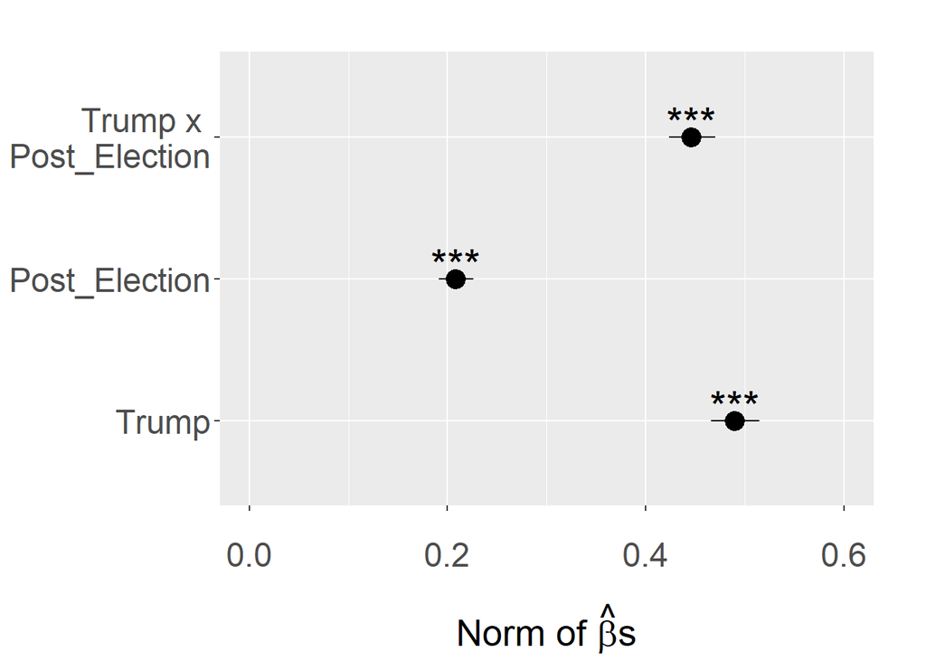

```r
# coefficient plot
plot_tibble <- model1@normed_coefficients %>%
  mutate(coefficient = c("Trump", "Post_Election", "Trump x \n Post_Election")) %>%
  mutate(coefficient = factor(coefficient, levels = coefficient))

ggplot(plot_tibble, aes(x = coefficient, y = normed.estimate)) +
  geom_pointrange(aes(ymin = lower.ci, ymax = upper.ci), size = 1) +
  labs(y = expression(paste('Norm of ', hat(beta),'s'))) +
  geom_text(aes(label=c('***', '***', '***')), position=position_dodge(width=0.9), hjust=0.5, vjust = c(0, 0, 0), size = 8) +
  coord_flip() +
  ylim(0,0.6) +
  theme(axis.text.x = element_text(size=18, vjust = 0.5, margin = margin(t = 15, r = 0, b = 15, l = 0)),
        axis.text.y = element_text(size=18),
        axis.title.y = element_blank(),
        axis.title.x = element_text(size=20),
        plot.margin=unit(c(1,1,0,0),"cm"))
```